# Reglas de Asociación

Grupo G3 - Los Panteras

2020-06-14

**NOTA IMPORTANTE:** El conjunto de datos que estudiamos en este apartado de reglas de asociación no está extraído de una fuente oficial como podría ser la web de la junta de Andalucía o el Gobierno de España como se han extraído en otros apartados. Por ello, no podemos verificar con total seguridad el resultado obtenido tras nuestro análisis, pero podemos obtener resultados interesantes y podemos comprobar que con este análisis realizado a este conjunto de datos se puede sacar información valiosa para combatir contra el virus.

### Pre-procesamiento

```r
library(arules)
library(arulesViz)
library(dplyr)
library(rmarkdown)
library(readr)
```

```r
sick_patients <- read_csv("Datasets/sick_patients.csv")
# Cargamos en una nueva variable las columnas a estudiar:

sick_patients2 <- sick_patients[, 2:20]

# Preprocesamos el dataset para buscar las reglas:

# convertimos a factor de dos niveles (0,1) -> TRUE OR FALSE todas las columnas.
sick_patients2[] <- lapply(sick_patients2, factor)
col_names <- names(sick_patients2)
sick_patients2[col_names] <- lapply(sick_patients2[col_names] , factor)

# Convertimos a transaction el df para poder crear reglas.
sick_patients2 <- as(sick_patients2, "transactions")

str(sick_patients2)
```

```
## Formal class 'transactions' [package "arules"] with 3 slots
##   ..@ data       :Formal class 'ngCMatrix' [package "Matrix"] with 5 slots
##   .. .. ..@ i       : int [1:6019200] 1 3 5 7 9 10 13 15 17 19 ...
##   .. .. ..@ p       : int [1:316801] 0 19 38 57 76 95 114 133 152 171 ...
##   .. .. ..@ Dim     : int [1:2] 38 316800
##   .. .. ..@ Dimnames:List of 2
##   .. .. .. ..$ : NULL
##   .. .. .. ..$ : NULL
##   .. .. ..@ factors : list()
##   ..@ itemInfo   :'data.frame':  38 obs. of  3 variables:
##   .. ..$ labels   : chr [1:38] "Fever=0" "Fever=1" "Tiredness=0" "Tiredness=1" ...
##   .. ..$ variables: Factor w/ 19 levels "Age_0-9","Age_10-19",..: 10 10 19 19 9 9 8 8 18 18 ...
##   .. ..$ levels   : Factor w/ 2 levels "0","1": 1 2 1 2 1 2 1 2 1 2 ...
##   ..@ itemsetInfo:'data.frame':  316800 obs. of  1 variable:
##   .. ..$ transactionID: chr [1:316800] "1" "2" "3" "4" ...
```

```r
dim(sick_patients2)
```

```
## [1] 316800     38
```

### Reglas de Asociación

Para realizar un primer análisis del conjunto de todas las reglas, realizamos el método a priori de reglas de asociación, con 10% como mínimo de soporte de un itemset.

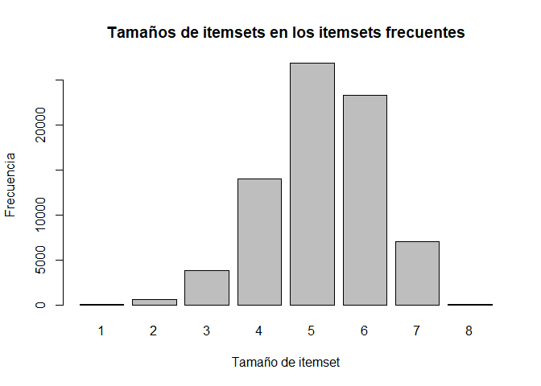

```r
i_sick <- apriori(sick_patients2,
              parameter = list(support = 0.1, target = "frequent"),
              control = list(verbose = FALSE))

# Se ordenan las reglas por el valor del soporte
i_sick <- sort(i_sick, by = "support")

# Itemsets frecuentes
barplot(table(size(i_sick)),
        xlab = "Tamaño de itemset", ylab = "Frecuencia",
        main = "Tamaños de itemsets en los itemsets frecuentes")
```

Se calculan los itemsets maximales y cerrados.

```r
# Itemsets maximales
imaxSick <- i_sick[is.maximal(i_sick)]

# Itemsets cerrados
icloSick <- i_sick[is.closed(i_sick)]
```

Se muestran en un gráfico el número de itemsets frecuentes, cerrados y maximales:

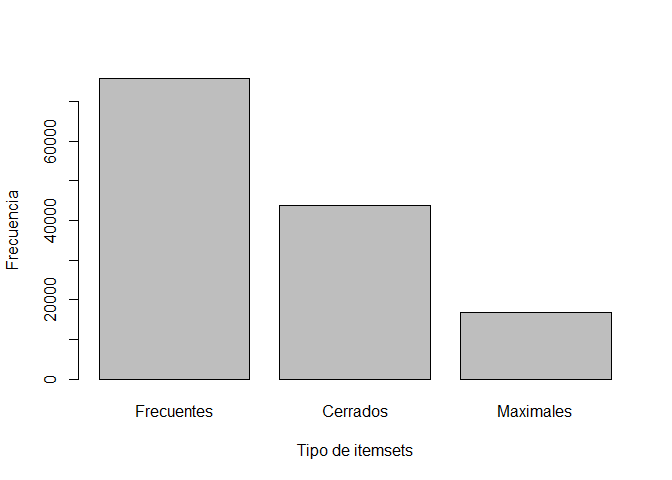

```r
barplot(c(Frecuentes = length(i_sick),
          Cerrados = length(icloSick),
          Maximales = length(imaxSick)),
        ylab = "Frecuencia", xlab = "Tipo de itemsets")
```

**Estudio concreto COVID-19**

Como primer foco de estudio, queremos encontrar reglas que muestren qué sintomas son los que causan el COVID19. Por ello, buscaremos reglas donde el consecuente sea COVID19 = 1.

```r
r1 <- apriori(sick_patients2, list(supp = 0.1, conf = 0.3), appearance = list(default = "lhs", rhs = "Covid_19=1"))
```

```
## Apriori
##
## Parameter specification:
##  confidence minval smax arem  aval originalSupport maxtime support minlen
##         0.3    0.1    1 none FALSE            TRUE       5     0.1      1
##  maxlen target   ext
##      10  rules FALSE
##
## Algorithmic control:
##  filter tree heap memopt load sort verbose
##     0.1 TRUE TRUE  FALSE TRUE    2    TRUE
##
## Absolute minimum support count: 31680
##
## set item appearances ...[1 item(s)] done [0.00s].
## set transactions ...[38 item(s), 316800 transaction(s)] done [0.29s].
## sorting and recoding items ... [36 item(s)] done [0.04s].
## creating transaction tree ... done [0.20s].
## checking subsets of size 1 2 3 4 5 6 7 8 done [1.16s].
## writing ... [1463 rule(s)] done [0.00s].
## creating S4 object  ... done [0.03s].
```

```r
length(r1)
```

```
## [1] 1463
```

```r
inspect(head(r1))
```

```
##     lhs                  rhs          support   confidence lift count
## [1] {}                => {Covid_19=1} 0.3333333 0.3333333  1    105600
## [2] {Fever=1}         => {Covid_19=1} 0.1041667 0.3333333  1     33000
## [3] {Sore-Throat=1}   => {Covid_19=1} 0.1041667 0.3333333  1     33000
## [4] {Gender_Female=1} => {Covid_19=1} 0.1111111 0.3333333  1     35200
## [5] {Gender_Male=1}   => {Covid_19=1} 0.1111111 0.3333333  1     35200
## [6] {Diarrhea=1}      => {Covid_19=1} 0.1212121 0.3333333  1     38400
```

En este caso, no nos interesa limpiar el conjunto de reglas buscando reglas reduntantes, pues al buscar reglas donde el consecuente siempre sea COVID19 = 1, se reduciría el conjunto de reglas a la regla:

{} => {Covid_19=1}

Dentro del conjunto de reglas, buscaremos las reglas donde el antecedente sean los síntomas:

```r
# Con %oin% podremos seleccionar las reglas que tengan al menos uno de los items en lhs.

sub1 <- subset(r1, subset=lhs%oin%c("Fever=1","Tiredness=1","Dry-Cough=1","Difficulty-in-Breathing=1","Sore-Throat=1","Pains=1","Nasal-Congestion=1","Runny-Nose=1", "Diarrhea=1"))
length(sub1)
```

```
## [1] 15
```

```r
inspect(tail(sub1))
```

```
##     lhs                                        rhs          support
## [1] {Dry-Cough=1}                           => {Covid_19=1} 0.1875000
## [2] {Tiredness=1,Dry-Cough=1}               => {Covid_19=1} 0.1250000
## [3] {Dry-Cough=1,Difficulty-in-Breathing=1} => {Covid_19=1} 0.1250000
## [4] {Nasal-Congestion=1,Runny-Nose=1}       => {Covid_19=1} 0.1212121
## [5] {Dry-Cough=1,Runny-Nose=1}              => {Covid_19=1} 0.1022727
## [6] {Dry-Cough=1,Nasal-Congestion=1}        => {Covid_19=1} 0.1022727
##     confidence lift count
## [1] 0.3333333  1    59400
## [2] 0.3333333  1    39600
## [3] 0.3333333  1    39600
## [4] 0.3333333  1    38400
## [5] 0.3333333  1    32400
## [6] 0.3333333  1    32400
```

Inspeccionando estas reglas podemos ver conjuntos de síntomas que se tienen con frecuencia cuando los pacientes dan positivos en COVID19.

Otra regla interesante sería por ejemplo, {Tiredness=1,Dry-Cough=1} => {Covid_19=1} que nos indica que los pacientes de nuestra base de conocimiento que dan positivos en COVID19, paceden *“cansancio”* y *“tos seca”* con una frecuencia de 39.600 veces.

### Visualizar conjuntos de reglas

Visualizamos el subconjunto de reglas según su soporte y confianza.

```
## To reduce overplotting, jitter is added! Use jitter = 0 to prevent jitter.
```

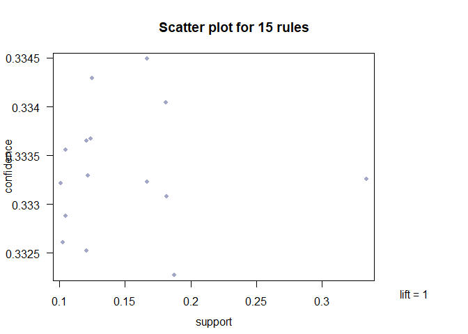

```r
library(colorspace)
plot(sub1, control = list(col=sequential_hcl(100)))
```

Ahora, nos centramos en los métodos de visualización proporcionados por el paquete ArulesViz:

Representamos el subconjunto de reglas como un grafo:

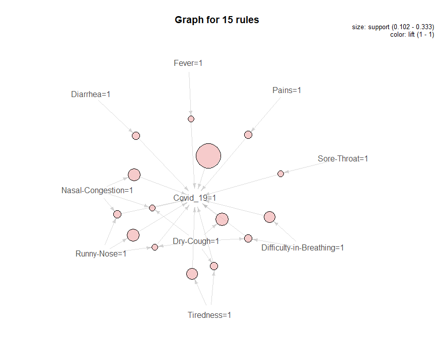

```r
plot(sub1, method = "graph")
```

Representamos las reglas como un diagrama de coordenadas paralelas:

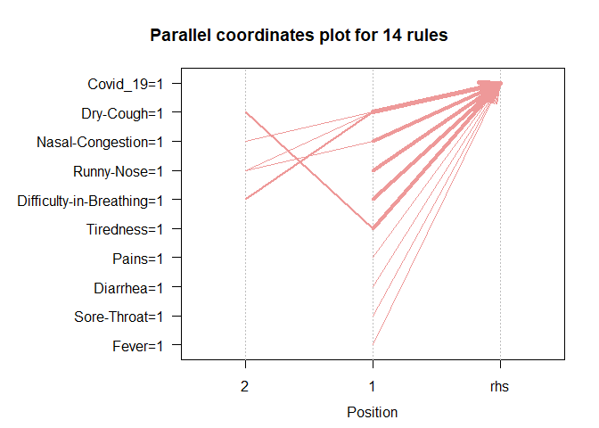

```r
plot(sub1, method = "paracoord")
```

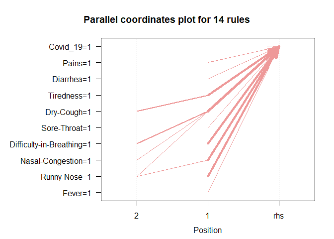

```r
# Si las ordenamos:
plot(sub1, method = "paracoord", control = list(reorder = TRUE))
```